# Project 1. Stroop effect.

*Author: Gulshat Badretdinova*

In a Stroop task, participants are presented with a list of words, with each word displayed in a color of ink. The participant’s task is to say out loud the color of the ink in which the word is printed. The task has two conditions: a congruent words condition, and an incongruent words condition. In the congruent words condition, the words being displayed are color words whose names match the colors in which they are printed: for example RED, BLUE. In the incongruent words condition, the words displayed are color words whose names do not match the colors in which they are printed: for example PURPLE, ORANGE. In each case, we measure the time it takes to name the ink colors in equallysized lists. Each participant will go through and record a time from each condition.

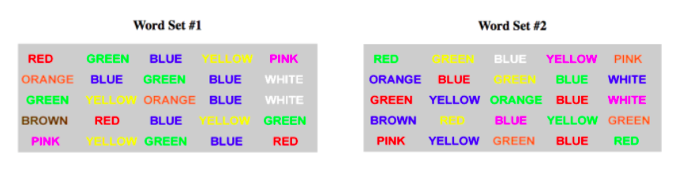

```python
# Add image
from IPython.display import Image
path = "/Users/gulsat/Desktop/statistics/P1/"
Image(filename = path + "word_set.png")
```

```python
%matplotlib inline
import matplotlib.pyplot as plt
import numpy as np
import pandas as pd
import math

location = r"/Users/gulsat/Desktop/statistics/P1/stroopdata.csv"
dataSchema = pd.read_csv(location)
dataSchema["Participant ID"] = dataSchema.index + 1 #Add participant ID
dataSchema
```

|  | Congruent | Incongruent | Participant ID |
| --- | --- | --- | --- |
| 0 | 12.079 | 19.278 | 1 |
| 1 | 16.791 | 18.741 | 2 |
| 2 | 9.564 | 21.214 | 3 |
| 3 | 8.630 | 15.687 | 4 |
| 4 | 14.669 | 22.803 | 5 |
| 5 | 12.238 | 20.878 | 6 |
| 6 | 14.692 | 24.572 | 7 |
| 7 | 8.987 | 17.394 | 8 |
| 8 | 9.401 | 20.762 | 9 |
| 9 | 14.480 | 26.282 | 10 |
| 10 | 22.328 | 24.524 | 11 |
| 11 | 15.298 | 18.644 | 12 |
| 12 | 15.073 | 17.510 | 13 |
| 13 | 16.929 | 20.330 | 14 |
| 14 | 18.200 | 35.255 | 15 |
| 15 | 12.130 | 22.158 | 16 |
| 16 | 18.495 | 25.139 | 17 |
| 17 | 10.639 | 20.429 | 18 |
| 18 | 11.344 | 17.425 | 19 |
| 19 | 12.369 | 34.288 | 20 |
| 20 | 12.944 | 23.894 | 21 |
| 21 | 14.233 | 17.960 | 22 |
| 22 | 19.710 | 22.058 | 23 |
| 23 | 16.004 | 21.157 | 24 |

### 1. Independent and dependent variable

- Independent - congruent words condition, incongruent words condition
- Dependent - Response Time in seconds

### 2. Dependent sample two-tailed t-test

The dependent samples two-tailed t-test is the appropriate methods for this tasks for these following reasons:

- We can compare two means from 2 samples for pre-test period and post-test period.
- The dataset doesn't include population μ and σ. We cann't conduct a z-test.

H0 - Null Hypothesis: ( μi - μc = 0 ) There is no significant difference in the population average response time in viewing the congruent(c) words vs viewing the incongruent(i) words.

HA - Alternative Hypothesis: ( μi - μc ≠ 0 ) There is a significant difference, positive or negative, in the population average response times.

### 3. Descriptive statistic.

```python
# Separate congruent and incongruent data

frame_congruent = dataSchema["Congruent"]
frame_icongruent = dataSchema["Incongruent"]
```

Report some descriptive statistics regarding this dataset. Include at least one measure of central tendency and at least one measure of variability.

```python
m_congruent = round(frame_congruent.mean(),2)
m_icongruent = round(frame_icongruent.mean(),2)
med_congruent = round(frame_congruent.median(),2)
med_icongruent = round(frame_icongruent.median(),2)
std_congruent = round(frame_congruent.std(),2)
std_icongruent = round(frame_icongruent.std(),2)
```

##### Central tendency measurement.

```python
print "Congruent mean: "
print m_congruent

print "Icongruent mean: "
print m_icongruent

print "Congruent median: "
print med_congruent

print "Icongruent median: "
print med_icongruent
```

```
Congruent mean:
14.05
Icongruent mean:
22.02
Congruent median:
14.36
Icongruent median:
21.02
```

##### Variability measurements

```python
print "Congruent standart deviation: "
print std_congruent

print "Icongruent standart deviation: "
print std_icongruent
```

```
Congruent standart deviation:
3.56
Icongruent standart deviation:
4.8
```

### 4. Data visualisation.

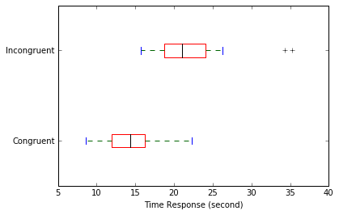

```python
dataSchema.plot(x = "Participant ID",
               kind = "box",
               vert = False,
               color = dict(boxes = "Red",
                           whiskers = "DarkGreen",
                           medians = "Black",
                           caps = "Blue")
               ).set_xlabel("Time Response (second)")
plt.show()
```

##### Observation:

Visually speaking, the box plot shows that the mean of incongruent response time may not be within the t-critical from congruent response time. Also, we can also see few outlier from "Incongruent" that could indicate the response time is significant higher if we take more sample size.

### 5. Statistical test and result.

Confidence Level = 90%

α=0.1

t-critical value (2-sided test) -> from t-table

df = 23

```python
# Calculate point estimate
estimate_p = round((m_icongruent - m_congruent),2)
print "Point estimate: "
print estimate_p
```

```
Point estimate:
7.97
```

```python
# Calculate SD difference between Cougruent and Incongruent.
dataSchema["D"] = dataSchema["Incongruent"] - dataSchema["Congruent"]
dataSchema["D"]
sd = round((np.std(dataSchema["D"], ddof = 1, dtype=np.float64)),3)
print "SD: "
print sd
```

```
SD:
4.865
```

```python
# Calculate t-statistic with n=24, point estimate = 7.97 and standart deviation
t = round(estimate_p/(sd/math.sqrt(24)),3)
print "t-statistic: "
print t
```

```
t-statistic:
8.026
```

#### Result

t-statistic = 8.026 > t-critical = 1.714 by a significant amount.

We reject the Null Hypothesis which states that there is no significant differences between the population average completion time for the two different conditions.